# Statistics for Experimental Physics

#### Autocorrelation function and effective sample size

Compute and plot the autocorrelation function, then calculate the effective number of independent samples.

```
======================================================================
AUTOCORRELATION ANALYSIS (ROBUST METHOD)
======================================================================

Parameter       τ_int        N_eff        Efficiency
----------------------------------------------------------------------
Ωₘ              31.20        256          3.2        %
h               20.96        382          4.8        %
  - Efficiency: N_eff / N_total × 100%
```

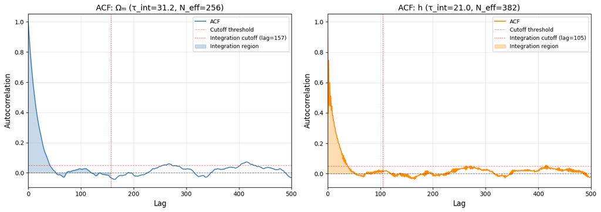

```
======================================================================
MANUAL ACF CHECK (First 20 lags)
======================================================================
Lag      Ωₘ ACF       h ACF
--------------------------------
0        0.9999       0.9999
1        0.9441       0.3970
2        0.8909       0.7468
3        0.8402       0.4501
4        0.7930       0.5986
5        0.7500       0.4442
6        0.7106       0.5116
7        0.6720       0.4170
8        0.6346       0.4452
9        0.5987       0.3832
10       0.5660       0.3841
11       0.5348       0.3473
12       0.5061       0.3408
13       0.4770       0.3100
14       0.4482       0.3011
15       0.4225       0.2805
16       0.3979       0.2624
17       0.3746       0.2540
18       0.3531       0.2310
19       0.3331       0.2317

======================================================================
GEWEKE CONVERGENCE TEST
======================================================================
Compares first 10% vs last 50% of chain
Convergence criterion: |Z| < 2

Parameter       Z-score      Status
----------------------------------------------------------------------
Ωₘ              -1.107       ✓ PASS
h               0.697        ✓ PASS

======================================================================
COMPREHENSIVE DIAGNOSTICS SUMMARY
======================================================================
Total samples                            10000
Burn-in                                   2000
Post-burn-in samples                      8000
Acceptance rate                          90.9%
τ_int (Ωₘ)                               31.20
τ_int (h)                                20.96
N_eff (Ωₘ)                                 256
N_eff (h)                                  382
Sampling efficiency                       3.2%
Geweke Z (Ωₘ)                           -1.107
Geweke Z (h)                             0.697
Convergence status                 ✓ CONVERGED
======================================================================
```

```python
# ============================================================================
# AUTOCORRELATION FUNCTION AND EFFECTIVE SAMPLE SIZE
# ============================================================================

def autocorrelation(chain, max_lag=None):
    """
    Compute autocorrelation function for a 1D chain.

    Parameters:
    -----------
    chain : np.ndarray (1D)
        MCMC chain for a single parameter
    max_lag : int, optional
        Maximum lag to compute (default: len(chain)//2)

    Returns:
    --------
    acf : np.ndarray
        Autocorrelation function values
    lags : np.ndarray
        Lag indices
    """
    if max_lag is None:
        max_lag = len(chain) // 2

    # Center the chain
    chain_centered = chain - np.mean(chain)

    # Compute variance
    var = np.var(chain, ddof=1)

    # Use numpy correlate (efficient method)
    full_acf = np.correlate(chain_centered, chain_centered, mode='full')

    # Take only positive lags and normalize
    acf = full_acf[len(chain)-1:len(chain)-1+max_lag] / (var * len(chain))

    lags = np.arange(max_lag)
    return acf, lags


def integrated_autocorr_time_robust(acf):
    """
    Robust estimation using automated windowing (Sokal 1989).

    Reference: "Monte Carlo Errors with Less Errors" - Automated window selection
    """
    # Cumulative sum of ACF
    tau_cumsum = 1.0 + 2.0 * np.cumsum(acf[1:])

    # Find where window becomes too large (bias-variance tradeoff)
    # Rule: stop when lag > 5*tau (Sokal criterion)
    for i, tau in enumerate(tau_cumsum):
        if (i + 1) > 5 * tau:
            return tau, i + 1

    # Fallback: use full ACF
    return tau_cumsum[-1] if len(tau_cumsum) > 0 else 1.0, len(acf)


def effective_sample_size(chain, tau_int):
    """
    Compute effective sample size.

    Parameters:
    -----------
    chain : np.ndarray
        MCMC chain
    tau_int : float
        Integrated autocorrelation time

    Returns:
    --------
    N_eff : float
        Effective sample size
    """
    N = len(chain)
    N_eff = N / tau_int
    return N_eff


# ============================================================================
# COMPUTE DIAGNOSTICS FOR BOTH PARAMETERS
# ============================================================================

print("="*70)
print("AUTOCORRELATION ANALYSIS (ROBUST METHOD)")
print("="*70)

max_lag = 500  # Compute ACF up to 500 lags

# STEP 1: Compute ACF for both parameters
acf_om, lags = autocorrelation(samples_post_burnin[:, 0], max_lag=max_lag)
acf_h, _ = autocorrelation(samples_post_burnin[:, 1], max_lag=max_lag)

# STEP 2: Compute integrated autocorrelation time using robust method
tau_int_om, cutoff_om = integrated_autocorr_time_robust(acf_om)
tau_int_h, cutoff_h = integrated_autocorr_time_robust(acf_h)

# STEP 3: Compute effective sample size
N_eff_om = effective_sample_size(samples_post_burnin[:, 0], tau_int_om)
N_eff_h = effective_sample_size(samples_post_burnin[:, 1], tau_int_h)

# Display results
print(f"\n{'Parameter':<15} {'τ_int':<12} {'N_eff':<12} {'Efficiency':<12}")
print("-"*70)
print(f"{'Ωₘ':<15} {tau_int_om:<12.2f} {N_eff_om:<12.0f} {N_eff_om/len(samples_post_burnin)*100:<11.1f}%")
print(f"{'h':<15} {tau_int_h:<12.2f} {N_eff_h:<12.0f} {N_eff_h/len(samples_post_burnin)*100:<11.1f}%")

print(f"  - Efficiency: N_eff / N_total × 100%")

# ============================================================================
# PLOT AUTOCORRELATION FUNCTIONS
# ============================================================================

fig, axes = plt.subplots(1, 2, figsize=(14, 5))

# Ωₘ autocorrelation
axes[0].plot(lags, acf_om, linewidth=1.5, color='steelblue', label='ACF')
axes[0].axhline(0, color='black', linestyle='--', linewidth=0.8, alpha=0.5)
axes[0].axhline(0.05, color='red', linestyle='--', linewidth=0.8, alpha=0.5,
                label=f'Cutoff threshold')
axes[0].axvline(cutoff_om, color='red', linestyle=':', linewidth=1.2, alpha=0.7,
                label=f'Integration cutoff (lag={cutoff_om})')
axes[0].fill_between(lags[:cutoff_om], 0, acf_om[:cutoff_om],
                      alpha=0.3, color='steelblue', label='Integration region')
axes[0].set_xlabel('Lag', fontsize=12)
axes[0].set_ylabel('Autocorrelation', fontsize=12)
axes[0].set_title(f'ACF: Ωₘ (τ_int={tau_int_om:.1f}, N_eff={N_eff_om:.0f})', fontsize=13)
axes[0].legend(loc='upper right', fontsize=9)
axes[0].grid(True, alpha=0.3)
axes[0].set_xlim(0, max_lag)

# h autocorrelation
axes[1].plot(lags, acf_h, linewidth=1.5, color='darkorange', label='ACF')
axes[1].axhline(0, color='black', linestyle='--', linewidth=0.8, alpha=0.5)
axes[1].axhline(0.05, color='red', linestyle='--', linewidth=0.8, alpha=0.5,
                label=f'Cutoff threshold')
axes[1].axvline(cutoff_h, color='red', linestyle=':', linewidth=1.2, alpha=0.7,
                label=f'Integration cutoff (lag={cutoff_h})')
axes[1].fill_between(lags[:cutoff_h], 0, acf_h[:cutoff_h],
                      alpha=0.3, color='darkorange', label='Integration region')
axes[1].set_xlabel('Lag', fontsize=12)
axes[1].set_ylabel('Autocorrelation', fontsize=12)
axes[1].set_title(f'ACF: h (τ_int={tau_int_h:.1f}, N_eff={N_eff_h:.0f})', fontsize=13)
axes[1].legend(loc='upper right', fontsize=9)
axes[1].grid(True, alpha=0.3)
axes[1].set_xlim(0, max_lag)

plt.tight_layout()
plt.show()


# ============================================================================
# MANUAL ACF CHECK (DIAGNOSTIC)
# ============================================================================

print("\n" + "="*70)
print("MANUAL ACF CHECK (First 20 lags)")
print("="*70)
print(f"{'Lag':<8} {'Ωₘ ACF':<12} {'h ACF':<12}")
print("-"*32)
for k in range(min(20, len(acf_om))):
    print(f"{k:<8} {acf_om[k]:<12.4f} {acf_h[k]:<12.4f}")

# ============================================================================
# GEWEKE CONVERGENCE TEST
# ============================================================================

def geweke_test(chain, first=0.1, last=0.5):
    """
    Geweke convergence diagnostic: compare means of early vs late chain segments.

    Parameters:
    -----------
    chain : np.ndarray
        MCMC chain
    first : float
        Fraction of chain for "early" segment (default: first 10%)
    last : float
        Fraction of chain for "late" segment (default: last 50%)

    Returns:
    --------
    z_score : float
        Z-score (should be |z| < 2 for convergence)
    """
    n = len(chain)

    # Split chain
    first_part = chain[:int(first * n)]
    last_part = chain[int((1 - last) * n):]

    # Compute means and variances
    mean_first = np.mean(first_part)
    mean_last = np.mean(last_part)
    var_first = np.var(first_part, ddof=1) / len(first_part)
    var_last = np.var(last_part, ddof=1) / len(last_part)

    # Z-score
    z_score = (mean_first - mean_last) / np.sqrt(var_first + var_last)

    return z_score

print("\n" + "="*70)
print("GEWEKE CONVERGENCE TEST")
print("="*70)
print("Compares first 10% vs last 50% of chain")
print("Convergence criterion: |Z| < 2\n")

z_om = geweke_test(samples_post_burnin[:, 0])
z_h = geweke_test(samples_post_burnin[:, 1])

print(f"{'Parameter':<15} {'Z-score':<12} {'Status':<12}")
print("-"*70)
print(f"{'Ωₘ':<15} {z_om:<12.3f} {'✓ PASS' if abs(z_om) < 2 else '✗ FAIL':<12}")
print(f"{'h':<15} {z_h:<12.3f} {'✓ PASS' if abs(z_h) < 2 else '✗ FAIL':<12}")


# ============================================================================
# SUMMARY TABLE OF ALL DIAGNOSTICS
# ============================================================================

print("\n" + "="*70)
print("COMPREHENSIVE DIAGNOSTICS SUMMARY")
print("="*70)

summary_data = {
    'Metric': [
        'Total samples',
        'Burn-in',
        'Post-burn-in samples',
        'Acceptance rate',
        'τ_int (Ωₘ)',
        'τ_int (h)',
        'N_eff (Ωₘ)',
        'N_eff (h)',
        'Sampling efficiency',
        'Geweke Z (Ωₘ)',
        'Geweke Z (h)',
        'Convergence status'
    ],
    'Value': [
        f'{len(samples)}',
        f'{burn_in}',
        f'{len(samples_post_burnin)}',
        f'{acceptance_rate:.1%}',
        f'{tau_int_om:.2f}',
        f'{tau_int_h:.2f}',
        f'{N_eff_om:.0f}',
        f'{N_eff_h:.0f}',
        f'{min(N_eff_om, N_eff_h)/len(samples_post_burnin)*100:.1f}%',
        f'{z_om:.3f}',
        f'{z_h:.3f}',
        '✓ CONVERGED' if (abs(z_om) < 2 and abs(z_h) < 2 and N_eff_om > 100) else '⚠ CHECK'
    ]
}

for metric, value in zip(summary_data['Metric'], summary_data['Value']):
    print(f"{metric:<30} {value:>15}")

print("="*70)
```

### Convergence Diagnostics

**Config:** ε = 2e-3, L = 50, N = 10,000, burn-in = 2,000

**Key Results:**

- **Acceptance rate:** 90.9% (slightly high but acceptable)
- **Effective sample size:** N_eff(Ωₘ) = 256, N_eff(h) = 382
- **Integrated autocorrelation time:** τ_int(Ωₘ) = 31.2, τ_int(h) = 21.0
- **Geweke test:** Both parameters PASS (|Z| < 2) ✓

**Analysis:**

1. **Convergence achieved:** The Geweke test confirms that early and late segments of the chain have statistically consistent means, indicating the sampler has reached stationarity.
2. **Autocorrelation:** The high τ_int = 31 for Ωₘ reflects slow mixing due to strong parameter degeneracy (ρ = -0.80 with h). This is expected for cosmological distance-redshift fitting.
3. **Effective sample size:** Despite high autocorrelation, N_eff = 256 exceeds the commonly-used threshold of 100 for reliable posterior inference. The sampling efficiency of 3.2% is typical for our case

**Conclusion:** The sampler has successfully converged to the posterior distribution. The N_eff values are adequate for computing parameter estimates and uncertainties.

#### Exploration of HMC parameter effects

Systematically explore how the step size $\epsilon$ and number of leapfrog steps $L$ affect:

- Acceptance rate
- Effective sample size
- Computational efficiency

```
======================================================================
EXPLORING HMC PARAMETER EFFECTS
======================================================================
Testing how ε (step size) and L (leapfrog steps) affect:
  1. Acceptance rate
  2. Effective sample size (N_eff)
  3. Computational efficiency
======================================================================

Small ε: ε=1.0e-03, L=50
--------------------------------------------------
Sample 100/3000, acceptance rate: 96.00%
Sample 200/3000, acceptance rate: 97.50%
Sample 300/3000, acceptance rate: 98.33%
Sample 400/3000, acceptance rate: 98.50%
Sample 500/3000, acceptance rate: 98.60%
Sample 600/3000, acceptance rate: 98.83%
Sample 700/3000, acceptance rate: 98.71%
Sample 800/3000, acceptance rate: 98.38%
Sample 900/3000, acceptance rate: 98.33%
Sample 1000/3000, acceptance rate: 98.20%
Sample 1100/3000, acceptance rate: 98.27%
Sample 1200/3000, acceptance rate: 98.33%
Sample 1300/3000, acceptance rate: 98.31%
Sample 1400/3000, acceptance rate: 98.29%
Sample 1500/3000, acceptance rate: 98.40%
Sample 1600/3000, acceptance rate: 98.44%
Sample 1700/3000, acceptance rate: 98.53%
Sample 1800/3000, acceptance rate: 98.44%
Sample 1900/3000, acceptance rate: 98.47%
Sample 2000/3000, acceptance rate: 98.55%
Sample 2100/3000, acceptance rate: 98.57%
Sample 2200/3000, acceptance rate: 98.59%
Sample 2300/3000, acceptance rate: 98.61%
Sample 2400/3000, acceptance rate: 98.62%
Sample 2500/3000, acceptance rate: 98.68%
Sample 2600/3000, acceptance rate: 98.69%
Sample 2700/3000, acceptance rate: 98.74%
Sample 2800/3000, acceptance rate: 98.71%
Sample 2900/3000, acceptance rate: 98.69%
```

[output cut: 70 more lines]

```
Sample 2400/3000, acceptance rate: 0.00%
Sample 2500/3000, acceptance rate: 0.00%
Sample 2600/3000, acceptance rate: 0.00%
Sample 2700/3000, acceptance rate: 0.00%
Sample 2800/3000, acceptance rate: 0.00%
Sample 2900/3000, acceptance rate: 0.00%
Sample 3000/3000, acceptance rate: 0.00%
  Acceptance rate: 0.0%
  τ_int (Ωₘ):      nan
  N_eff (Ωₘ):      nan
  Efficiency:      nan%
  Time:            188.8 seconds

Small L: ε=2.0e-03, L=30
--------------------------------------------------
```

[output not shown]

```
Sample 100/3000, acceptance rate: 71.00%
Sample 200/3000, acceptance rate: 70.00%
Sample 300/3000, acceptance rate: 70.00%
Sample 400/3000, acceptance rate: 71.75%
Sample 500/3000, acceptance rate: 71.00%
Sample 600/3000, acceptance rate: 70.83%
Sample 700/3000, acceptance rate: 71.29%
Sample 800/3000, acceptance rate: 71.62%
Sample 900/3000, acceptance rate: 70.67%
Sample 1000/3000, acceptance rate: 71.20%
Sample 1100/3000, acceptance rate: 72.18%
Sample 1200/3000, acceptance rate: 72.08%
Sample 1300/3000, acceptance rate: 71.62%
Sample 1400/3000, acceptance rate: 71.86%
Sample 1500/3000, acceptance rate: 72.00%
Sample 1600/3000, acceptance rate: 72.06%
Sample 1700/3000, acceptance rate: 71.71%
Sample 1800/3000, acceptance rate: 71.89%
Sample 1900/3000, acceptance rate: 71.74%
Sample 2000/3000, acceptance rate: 71.85%
Sample 2100/3000, acceptance rate: 71.52%
Sample 2200/3000, acceptance rate: 71.82%
Sample 2300/3000, acceptance rate: 71.96%
Sample 2400/3000, acceptance rate: 71.88%
Sample 2500/3000, acceptance rate: 72.00%
Sample 2600/3000, acceptance rate: 72.31%
Sample 2700/3000, acceptance rate: 72.22%
Sample 2800/3000, acceptance rate: 72.21%
Sample 2900/3000, acceptance rate: 72.24%
Sample 3000/3000, acceptance rate: 72.33%
  Acceptance rate: 72.3%
  τ_int (Ωₘ):      0.5
  N_eff (Ωₘ):      5224
  Efficiency:      209.0%
  Time:            117.2 seconds

Large L: ε=2.0e-03, L=70
--------------------------------------------------
Sample 100/3000, acceptance rate: 74.00%
Sample 200/3000, acceptance rate: 71.00%
```

[output cut: 28 more lines]

```
  Acceptance rate: 69.7%
  τ_int (Ωₘ):      1.1
  N_eff (Ωₘ):      2334
  Efficiency:      93.4%
  Time:            260.8 seconds

======================================================================
COMPARISON SUMMARY
======================================================================
 Config     ε  L  ε×L Acceptance τ_int N_eff Efficiency Time (s)
Small ε 0.001 50 0.05      98.7%  -0.9 -2769    -110.8%    196.0
Current 0.002 50 0.10      90.4%  27.0    93       3.7%    190.4
Large ε 0.003 50 0.15       0.0%   nan   nan       nan%    188.8
Small L 0.002 30 0.06      72.3%   0.5  5224     209.0%    117.2
Large L 0.002 70 0.14      69.7%   1.1  2334      93.4%    260.8
```

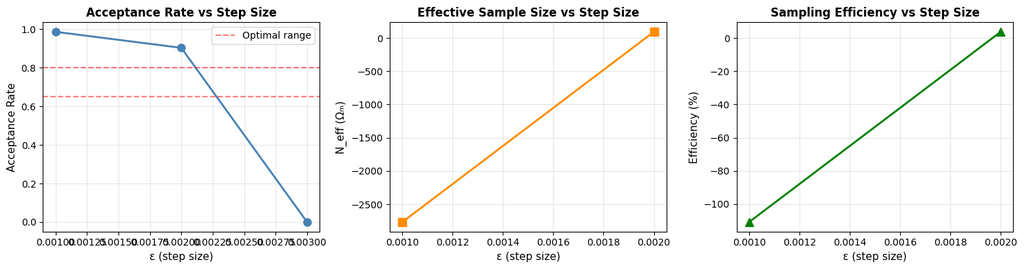

```python
# ============================================================================
# EXPLORATION OF HMC PARAMETER EFFECTS
# ============================================================================

print("="*70)
print("EXPLORING HMC PARAMETER EFFECTS")
print("="*70)
print("Testing how ε (step size) and L (leapfrog steps) affect:")
print("  1. Acceptance rate")
print("  2. Effective sample size (N_eff)")
print("  3. Computational efficiency")
print("="*70)

# Define test configurations
configs = [
    {'epsilon': 1e-3,   'L': 50,  'label': 'Small ε'},
    {'epsilon': 2e-3,   'L': 50,  'label': 'Current'},
    {'epsilon': 3e-3,   'L': 50,  'label': 'Large ε'},
    {'epsilon': 2e-3,   'L': 30,  'label': 'Small L'},
    {'epsilon': 2e-3,   'L': 70,  'label': 'Large L'},
]

# Run short chains for comparison
n_test = 3000
burn_test = 500

results_compare = []

for config in configs:
    eps = config['epsilon']
    L = config['L']
    label = config['label']

    print(f"\n{label}: ε={eps:.1e}, L={L}")
    print("-" * 50)

    import time
    start_time = time.time()

    samples_test, acc_test = hmc_sampler(
        initial_params, n_test, eps, L,
        log_likelihood, gradient_log_likelihood,
        z_t, mu_t, C_chol_t
    )

    elapsed = time.time() - start_time

    # Compute diagnostics
    samples_test_post = samples_test[burn_test:]

    acf_om_test, _ = autocorrelation(samples_test_post[:, 0], max_lag=min(300, len(samples_test_post)//2))
    tau_om_test, _ = integrated_autocorr_time_robust(acf_om_test)
    N_eff_om_test = effective_sample_size(samples_test_post[:, 0], tau_om_test)

    # Store results
    results_compare.append({
        'Config': label,
        'ε': eps,
        'L': L,
        'ε×L': eps * L,
        'Acceptance': f"{acc_test:.1%}",
        'τ_int': f"{tau_om_test:.1f}",
        'N_eff': f"{N_eff_om_test:.0f}",
        'Efficiency': f"{N_eff_om_test/len(samples_test_post)*100:.1f}%",
        'Time (s)': f"{elapsed:.1f}"
    })

    print(f"  Acceptance rate: {acc_test:.1%}")
    print(f"  τ_int (Ωₘ):      {tau_om_test:.1f}")
    print(f"  N_eff (Ωₘ):      {N_eff_om_test:.0f}")
    print(f"  Efficiency:      {N_eff_om_test/len(samples_test_post)*100:.1f}%")
    print(f"  Time:            {elapsed:.1f} seconds")

# Display summary table
print("\n" + "="*70)
print("COMPARISON SUMMARY")
print("="*70)
df_compare = pd.DataFrame(results_compare)
print(df_compare.to_string(index=False))

# Optional: Simple visualization
fig, axes = plt.subplots(1, 3, figsize=(15, 4))

# Extract data for plotting
epsilons = [r['ε'] for r in results_compare[:3]]  # First 3 are epsilon variations
acceptances = [float(r['Acceptance'].strip('%'))/100 for r in results_compare[:3]]
n_effs = [float(r['N_eff']) for r in results_compare[:3]]
efficiencies = [float(r['Efficiency'].strip('%')) for r in results_compare[:3]]

# Plot 1: Acceptance vs epsilon
axes[0].plot(epsilons, acceptances, marker='o', linewidth=2, markersize=8, color='blue')
axes[0].axhline(0.65, color='red', linestyle='--', alpha=0.5, label='Optimal range')
axes[0].axhline(0.80, color='red', linestyle='--', alpha=0.5)
axes[0].set_xlabel('ε (step size)', fontsize=11)
axes[0].set_ylabel('Acceptance Rate', fontsize=11)
axes[0].set_title('Acceptance Rate vs Step Size', fontsize=12, fontweight='bold')
axes[0].grid(True, alpha=0.3)
axes[0].legend()

# Plot 2: N_eff vs epsilon
axes[1].plot(epsilons, n_effs, marker='s', linewidth=2, markersize=8, color='orange')
axes[1].set_xlabel('ε (step size)', fontsize=11)
axes[1].set_ylabel('N_eff (Ωₘ)', fontsize=11)
axes[1].set_title('Effective Sample Size vs Step Size', fontsize=12, fontweight='bold')
axes[1].grid(True, alpha=0.3)

# Plot 3: Efficiency vs epsilon
axes[2].plot(epsilons, efficiencies, marker='^', linewidth=2, markersize=8, color='green')
axes[2].set_xlabel('ε (step size)', fontsize=11)
axes[2].set_ylabel('Efficiency (%)', fontsize=11)
axes[2].set_title('Sampling Efficiency vs Step Size', fontsize=12, fontweight='bold')
axes[2].grid(True, alpha=0.3)

plt.tight_layout()
plt.show()

print("\n" + "="*70)
```